# 0. Visualisation de chemins

Lecture du fichier des villes de la France:

```r
villes <- read.csv('Data/DonneesGPSvilles.csv',header=TRUE,dec='.',sep=';',quote="\"")
```

Représentation des chemins par plus proches voisins et du chemin optimal :

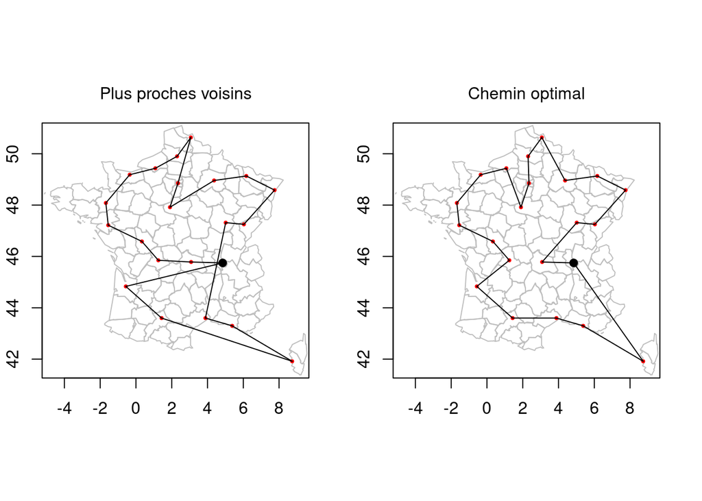

```r
coord <- cbind(villes$longitude,villes$latitude)
dist <- distanceGPS(coord)
voisins <- TSPnearest(dist)
pathOpt <- c(1,8,9,4,21,13,7,10,3,17,16,20,6,19,15,18,11,5,22,14,12,2)
par(mfrow=c(1,2),mar=c(1,1,2,1))
plotTrace(coord[voisins$chemin,], title='Plus proches voisins')
plotTrace(coord[pathOpt,], title='Chemin optimal')
```

Les longueurs des trajets (à vol d’oiseau) valent respectivement, pour la méthode des plus proches voisins :

```
## [1] 4303.568
```

pour la méthode branch and bound :

```
## [1] 3793.06
```

et pour la méthode optimale :

```
## [1] 3793.06
```

Nous voyons clairement que la méthode de plus proches voisins trouve un chemin moins optimal que la méthode branch and bound. De plus le chemin trouvé par cette méthode est bien plus long que le chemin optimale. Ceci illustre bien l’intérêt d’un algorithme de voyageur de commerce. Nous allons dans la suite étudier les performances de cet algorithme.

# 1. Comparaison d’algorithmes

Nous allons comparer Nombre de sommets fixes et graphes “identiques”.

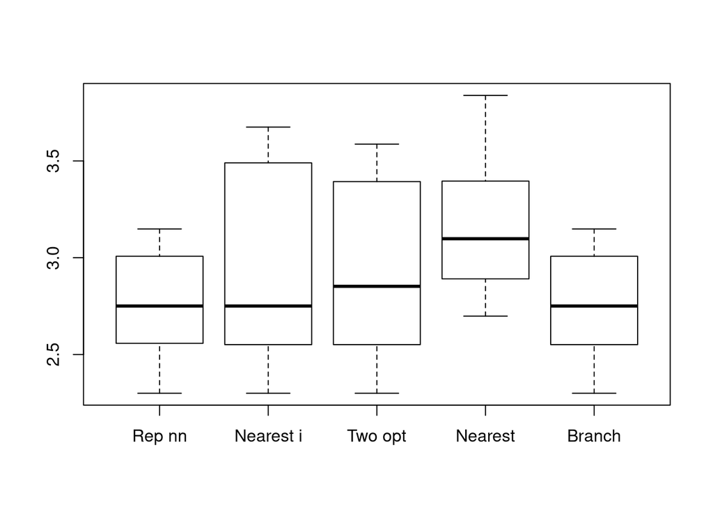

```r
nb_essais <- 5
d_hamil <- matrix(0,nrow=nb_essais,ncol=5)
for (i in 1:nb_essais) {
  n <- 10
  sommets <- data.frame(x = runif(n), y = runif(n))
  couts <- distance(sommets)
  d_hamil[i, 1] <- TSPsolve(couts, 'repetitive_nn')
  d_hamil[i, 2] <- TSPsolve(couts, 'nearest_insertion')
  d_hamil[i, 3] <- TSPsolve(couts, 'two_opt')
  d_hamil[i, 4] <- TSPsolve(couts, 'nearest')
  d_hamil[i, 5] <- TSPsolve(couts, 'branch')
}
colnames(d_hamil) <- c('Rep nn','Nearest i','Two opt','Nearest','Branch')
par(mfrow=c(1,1))
boxplot(d_hamil)
```